# Modelo de recomendación de hoteles

25 de junio de 2015

## Antecedentes

- **Objetivo:** Recomendar hoteles similares a uno dado
- **Solución actual:** búsqueda por destino y estrellas
- **Problemas:**
  - No se toma en cuenta la filosofía del hotel
  - No se aprovecha toda la información disponible
  - El criterio es más o menos estático
- **Ideas:**
  - Tomar en cuenta el perfil de los hoteles
  - Incorporar información geográfica
  - Hacer que el criterio sea dinámico

## Plan de ataque

1. Obtener información relevante
   - Servicios
   - Geolocalización
   - Precios recientes
2. Caracterizar los hoteles
   - Categorías de servicios equivalentes
3. Generar un criterio integral de similitud
   - Cercanía
   - Precio
   - Al menos los mismos servicios
   - Perfil similar

## Información

- Nos la saltaremos…

## Caracterización de hoteles

- Usar servicios es miope
- No toma en cuenta los sustitutos
- Agrupar servicios manualmente con modelo de apoyo:

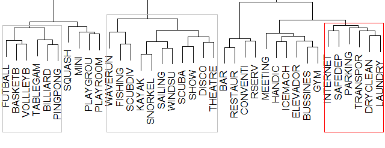

## Precio y cercanía

- **Precio:**
  - Favorecer precios bajos
  - Porcentaje máximo arriba del hotel original
- **Cercanía:**
  - Criterio dinámico
  - Depende de densidad de hoteles
  - Evita enmascaramiento por hoteles distintos
  - Gráfica

## Cercanía

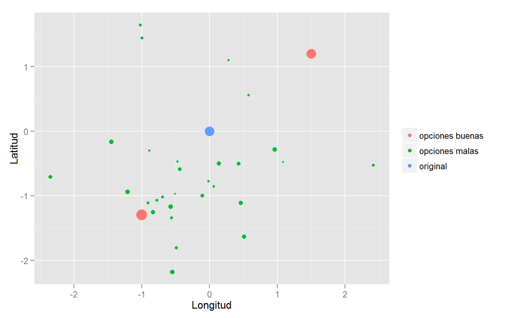

## Similaridad

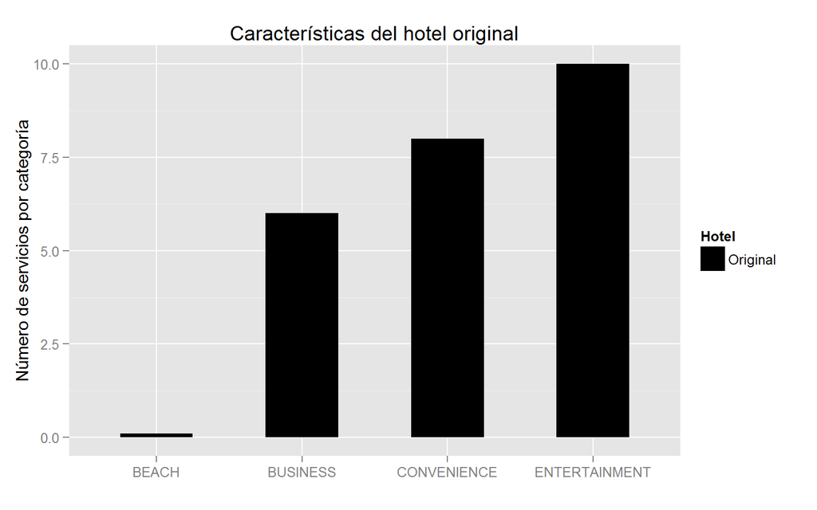

## Similaridad

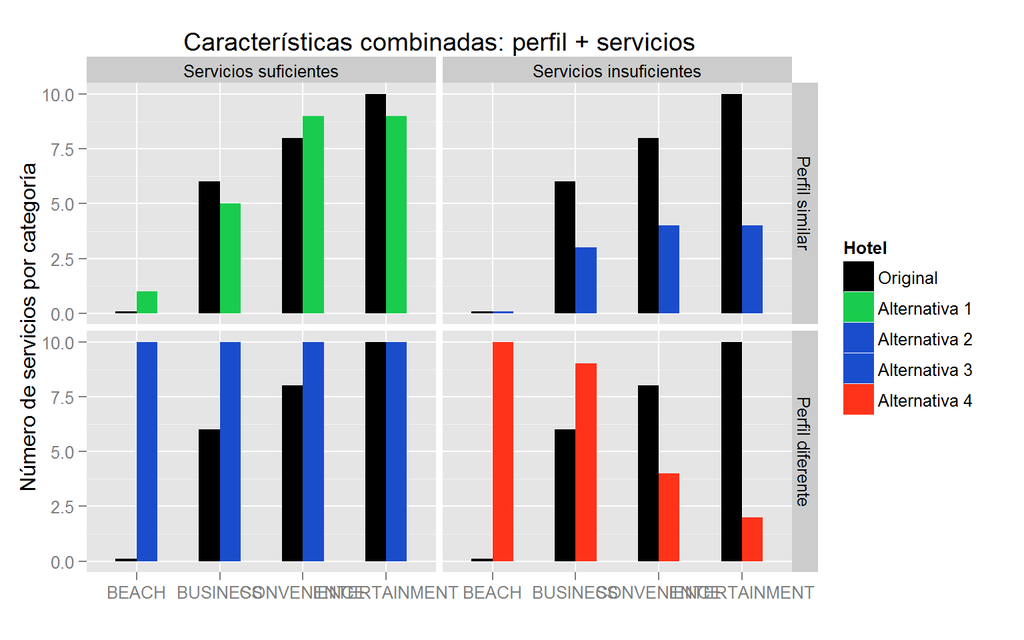

## Comentarios finales

- La base de servicios **no está homologada** para los demás países
- El modelo actual sólo está hecho con los datos de México
- Falta por definir algunos detalles del modelo